# Chlorophyll analysis

AS Huffmyer

2022

This script analyzes and plots data for Symbiotic Integration 2021 chlorophyll.

# **Setup**

Load libraries.

```r
library(dplyr)
library(readr)
library(stringr)
library(gridExtra)
```

```r
library(grid)
library(ggplot2)
library(lattice)
library(Rmisc)
library(ggpubr)
library(lsmeans)
library(tidyverse)
```

# **Load data**

Load data.

```r
metadata<-read_csv("Mcap2021/Data/Chlorophyll/platemap.csv")
chl630<-read_csv("Mcap2021/Data/Chlorophyll/630_chl.csv")
chl663<-read_csv("Mcap2021/Data/Chlorophyll/663_chl.csv")
chl750<-read_csv("Mcap2021/Data/Chlorophyll/750_chl.csv")
volumes<-read_csv("Mcap2021/Data/Resuspension_volumes.csv")
```

Modify column names and join together.

```r
names(chl630)<-c("Well", "c630")
names(chl663)<-c("Well", "c663")
names(chl750)<-c("Well", "c750")

head(chl630)
```

```
## # A tibble: 6 × 2
##   Well   c630
##   <chr> <dbl>
## 1 A1    0.03
## 2 B1    0.032
## 3 C1    0.031
## 4 D1    0.032
## 5 E1    0.033
## 6 F1    0.028
```

```r
head(chl663)
```

```
## # A tibble: 6 × 2
##   Well   c663
##   <chr> <dbl>
## 1 A1    0.028
## 2 B1    0.047
## 3 C1    0.037
## 4 D1    0.042
## 5 E1    0.044
## 6 F1    0.028
```

```r
head(chl750)
```

```
## # A tibble: 6 × 2
##   Well   c750
##   <chr> <dbl>
## 1 A1    0.028
## 2 B1    0.029
## 3 C1    0.029
## 4 D1    0.029
## 5 E1    0.029
## 6 F1    0.028
```

```r
chl_data<-left_join(left_join(chl630, chl663), chl750)
head(chl_data)
```

```
## # A tibble: 6 × 4
##   Well   c630  c663  c750
##   <chr> <dbl> <dbl> <dbl>
## 1 A1    0.03  0.028 0.028
## 2 B1    0.032 0.047 0.029
## 3 C1    0.031 0.037 0.029
## 4 D1    0.032 0.042 0.029
## 5 E1    0.033 0.044 0.029
## 6 F1    0.028 0.028 0.028
```

```r
chl_data<-left_join(chl_data, metadata)
head(chl_data)
```

```
## # A tibble: 6 × 9
##   Well   c630  c663  c750 Tube.ID Sample.Type Volume Sample.ID Treatment
##   <chr> <dbl> <dbl> <dbl> <chr>   <chr>        <dbl> <chr>     <chr>
## 1 A1    0.03  0.028 0.028 BLANK-1 Blank          200 <NA>      <NA>
## 2 B1    0.032 0.047 0.029 A       Sample         200 A         Ambient
## 3 C1    0.031 0.037 0.029 B       Sample         200 B         Ambient
## 4 D1    0.032 0.042 0.029 E       Sample         200 E         Ambient
## 5 E1    0.033 0.044 0.029 C       Sample         200 C         Ambient
## 6 F1    0.028 0.028 0.028 <NA>    Sample         200 <NA>      <NA>
```

Calculate blank values.

```r
Blank <- chl_data %>%
  filter(Sample.Type == "Blank") %>%
  summarise(blk.avg = mean(c750))
Blank
```

```
##   blk.avg
## 1   0.029
```

Subtract blanks from 630 and 663 values and account for path length correction.

```r
# Subtracting 750 (blank) from 630 and 663 values, and accounting for path length (0.584 cm)
chl_data$c630.corr <- (chl_data$c630 - Blank$blk.avg) / 0.584
chl_data$c663.corr <- (chl_data$c663 - Blank$`blk.avg`) / 0.584
head(chl_data)
```

```
## # A tibble: 6 × 11
##   Well   c630  c663  c750 Tube.ID Sample.Type Volume Sample.ID Treatment
##   <chr> <dbl> <dbl> <dbl> <chr>   <chr>        <dbl> <chr>     <chr>
## 1 A1    0.03  0.028 0.028 BLANK-1 Blank          200 <NA>      <NA>
## 2 B1    0.032 0.047 0.029 A       Sample         200 A         Ambient
## 3 C1    0.031 0.037 0.029 B       Sample         200 B         Ambient
## 4 D1    0.032 0.042 0.029 E       Sample         200 E         Ambient
## 5 E1    0.033 0.044 0.029 C       Sample         200 C         Ambient
## 6 F1    0.028 0.028 0.028 <NA>    Sample         200 <NA>      <NA>
## # … with 2 more variables: c630.corr <dbl>, c663.corr <dbl>
```

Calculate chl a and chl c2.

```r
# Chlorphyll A concentration equation
chl_data$chlA.ug.sample <- 11.43*chl_data$c663.corr - 0.64*chl_data$c630.corr

# Chlorophyll C2 concentration equation
chl_data$chlC2.ug.sample <- 27.09*chl_data$c630.corr - 3.63*chl_data$c663.corr

head(chl_data)
```

```
## # A tibble: 6 × 13
##   Well   c630  c663  c750 Tube.ID Sample.Type Volume Sample.ID Treatment
##   <chr> <dbl> <dbl> <dbl> <chr>   <chr>        <dbl> <chr>     <chr>
## 1 A1    0.03  0.028 0.028 BLANK-1 Blank          200 <NA>      <NA>
## 2 B1    0.032 0.047 0.029 A       Sample         200 A         Ambient
## 3 C1    0.031 0.037 0.029 B       Sample         200 B         Ambient
## 4 D1    0.032 0.042 0.029 E       Sample         200 E         Ambient
## 5 E1    0.033 0.044 0.029 C       Sample         200 C         Ambient
## 6 F1    0.028 0.028 0.028 <NA>    Sample         200 <NA>      <NA>
## # … with 4 more variables: c630.corr <dbl>, c663.corr <dbl>,
## #   chlA.ug.sample <dbl>, chlC2.ug.sample <dbl>
```

Bring in volume data.

```r
#Add a sample column to the volume data frame and select for only symbiont tubes
volumes_sym<-volumes%>%
  separate(Tube.ID, c("Sample.ID", "Fraction"))%>%
  filter(Fraction=="Symb")%>%
  dplyr::rename(Tube.ID=Sample.ID)

head(volumes_sym)
```

```
## # A tibble: 6 × 3
##   Tube.ID Fraction Resuspension_volume
##   <chr>   <chr>                  <dbl>
## 1 A       Symb                     250
## 2 B       Symb                     200
## 3 C       Symb                     200
## 4 D       Symb                     150
## 5 E       Symb                     200
## 6 F       Symb                     200
```

```r
df<-left_join(chl_data, volumes_sym, by="Tube.ID")
head(df)
```

```
## # A tibble: 6 × 15
##   Well   c630  c663  c750 Tube.ID Sample.Type Volume Sample.ID Treatment
##   <chr> <dbl> <dbl> <dbl> <chr>   <chr>        <dbl> <chr>     <chr>
## 1 A1    0.03  0.028 0.028 BLANK-1 Blank          200 <NA>      <NA>
## 2 B1    0.032 0.047 0.029 A       Sample         200 A         Ambient
## 3 C1    0.031 0.037 0.029 B       Sample         200 B         Ambient
## 4 D1    0.032 0.042 0.029 E       Sample         200 E         Ambient
## 5 E1    0.033 0.044 0.029 C       Sample         200 C         Ambient
## 6 F1    0.028 0.028 0.028 <NA>    Sample         200 <NA>      <NA>
## # … with 6 more variables: c630.corr <dbl>, c663.corr <dbl>,
## #   chlA.ug.sample <dbl>, chlC2.ug.sample <dbl>, Fraction <chr>,
## #   Resuspension_volume <dbl>
```

Multiply by resuspension volume to obtain chl concentrations in ug per uL.

```r
df$chlA.ug.uL<-df$chlA.ug.sample*df$Resuspension_volume

df$chlC2.ug.uL<-df$chlC2.ug.sample*df$Resuspension_volume
```

# **View sample calculations and replicates**

Plot values for each sample to identify any discrepancies between replicates.

Chl A

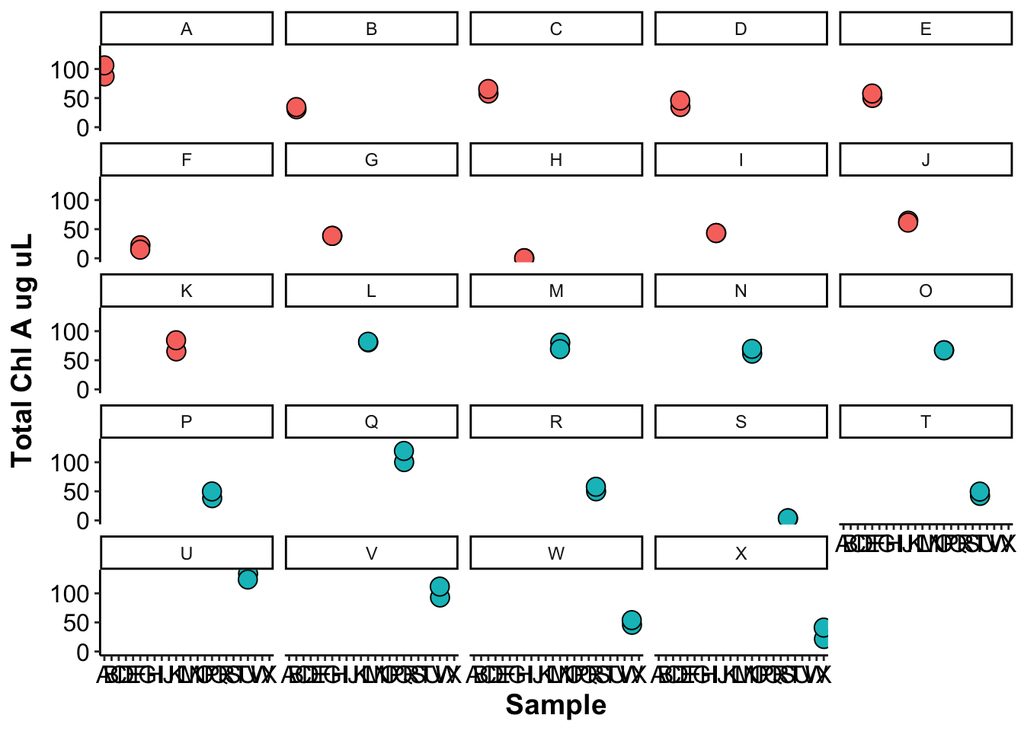

```r
rep_plot<-df %>%
    filter(Sample.Type=="Sample")%>%
    filter(!Treatment=="NA")%>%
    droplevels()%>%
    ggplot(., aes(x = Sample.ID, y = chlA.ug.uL)) +
    facet_wrap(~Sample.ID)+
    geom_point(aes(fill=Treatment, group=Treatment), pch = 21, size=4, position = position_jitterdodge(0.1)) +
    xlab("Sample") +
    ylab(expression(bold(paste("Total Chl A ug uL"))))+
    scale_color_manual(values=c("blue", "red"))+
    theme_classic() +
    theme(
      legend.position="none",
      axis.title=element_text(face="bold", size=14),
      axis.text=element_text(size=12, color="black"),
      legend.title=element_text(face="bold", size=14),
      legend.text=element_text(size=12)
      ); rep_plot
```

Chl C2

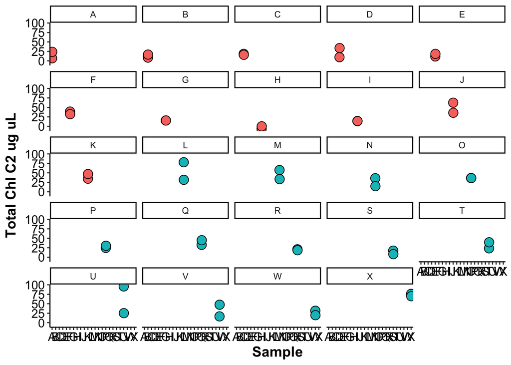

```r
rep_plot<-df %>%
    filter(Sample.Type=="Sample")%>%
    filter(!Treatment=="NA")%>%
    droplevels()%>%
    ggplot(., aes(x = Sample.ID, y = chlC2.ug.uL)) +
    facet_wrap(~Sample.ID)+
    geom_point(aes(fill=Treatment, group=Treatment), pch = 21, size=4, position = position_jitterdodge(0.1)) +
    xlab("Sample") +
    ylab(expression(bold(paste("Total Chl C2 ug uL"))))+
    scale_color_manual(values=c("blue", "red"))+
    theme_classic() +
    theme(
      legend.position="none",
      axis.title=element_text(face="bold", size=14),
      axis.text=element_text(size=12, color="black"),
      legend.title=element_text(face="bold", size=14),
      legend.text=element_text(size=12)
      ); rep_plot
```

Summarize by sample for ChlA and ChlC2.

```r
df_mean<-df%>%
  filter(Sample.Type=="Sample")%>%
  filter(!Sample.ID=="H")%>%
  drop_na()%>%
  group_by(Sample.ID, Tube.ID, Treatment, Fraction, Resuspension_volume)%>%
  dplyr::summarise(mean_chlA.ug.ul=mean(chlA.ug.uL), mean_chlC2.ug.ul=mean(chlC2.ug.uL))%>%
  mutate(total.chl.ug.uL=mean_chlA.ug.ul+mean_chlC2.ug.ul)
```

[output not shown]

# **Normalize to protein**

First, calculate protein per uL from the “Holo” tube for each sample, from which we took the symbiont sample.

```r
protein<-read.csv("Mcap2021/Output/Protein/protein_output.csv")

protein<-protein%>%
  dplyr::select(Sample.ID, Fraction, Protein.ug)%>%
  dplyr::rename(Tube.ID=Sample.ID)

volumes<-read_csv("Mcap2021/Data/Resuspension_volumes.csv")
volumes<-volumes%>%
  separate(Tube.ID, c("Tube.ID", "Fraction"))

volumes$Fraction <- ifelse(volumes$Fraction == "Holo", "Holobiont", volumes$Fraction)  #rename holobiont

protein<-left_join(protein, volumes)
protein$protein.ug.uL<-protein$Protein.ug/protein$Resuspension_volume

protein<-protein%>%
  filter(Fraction=="Holobiont")
```

Next, divide chlA and chlC2 (ug.uL) by protein (ug.uL) for each sample.

```r
df_mean$protein.ug.uL<-protein$protein.ug.uL[match(df_mean$Tube.ID, protein$Tube.ID)]
```

Normalize to total protein.

```r
df_mean$chlA.ug.protein.ug<-df_mean$mean_chlA.ug.ul/df_mean$protein.ug.uL
df_mean$chlC2.ug.protein.ug<-df_mean$mean_chlC2.ug.ul/df_mean$protein.ug.uL
df_mean$total.chl.ug.protein.ug<-df_mean$total.chl.ug.uL/df_mean$protein.ug.uL
```

Plot results.

## ChlA

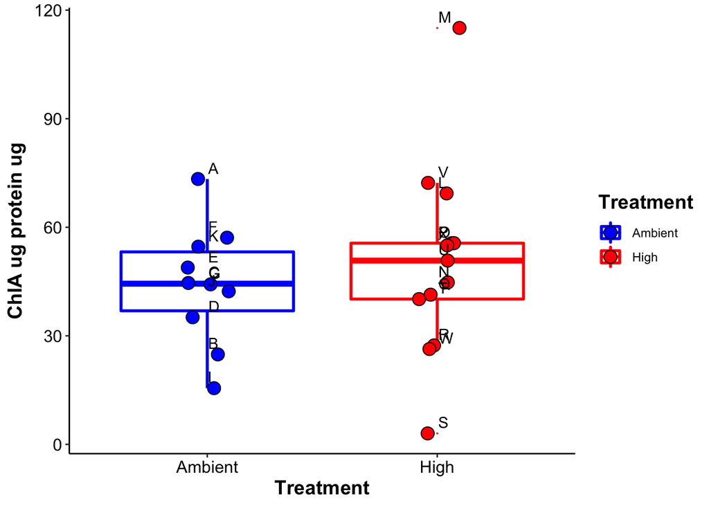

```r
chlA_protein_plot<-df_mean %>%
    #filter(!Sample.ID=="H")%>%
    ggplot(., aes(x = as.factor(Treatment), y = chlA.ug.protein.ug)) +
    geom_boxplot(aes(color=Treatment), outlier.size = 0, lwd=1) +
    geom_point(aes(fill=Treatment), pch = 21, size=4, position = position_jitterdodge(0.2)) +
    scale_fill_manual(values=c("blue", "red"))+
  scale_color_manual(values=c("blue", "red"))+
    geom_text(aes(label=Sample.ID), vjust = -0.5, hjust=-0.1)+
    xlab("Treatment") +
    ylab(expression(bold(paste("ChlA ug protein ug"))))+
    theme_classic() +
    theme(
      legend.position="right",
      axis.title=element_text(face="bold", size=14),
      axis.text=element_text(size=12, color="black"),
      legend.title=element_text(face="bold", size=14)
      ); chlA_protein_plot
```

Run ANOVA.

```r
chla_prot_model<-aov(chlA.ug.protein.ug~Treatment, data=df_mean)
summary(chla_prot_model)
```

```
##             Df Sum Sq Mean Sq F value Pr(>F)
## Treatment    1    235   235.5   0.446  0.512
## Residuals   21  11097   528.4
```

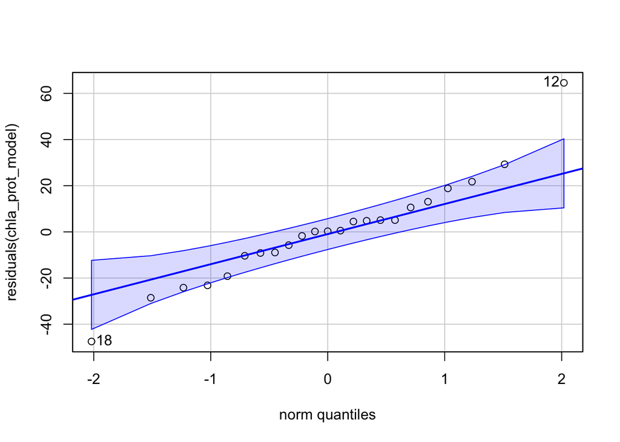

```
## [1] 12 18
```

```r
car::qqPlot(residuals(chla_prot_model))
```

```r
car::leveneTest(residuals(chla_prot_model)~Treatment, data=df_mean)
```

```
## Levene's Test for Homogeneity of Variance (center = median)
##       Df F value Pr(>F)
## group  1  1.0322 0.3212
##       21
```

No significant difference.

## ChlC2

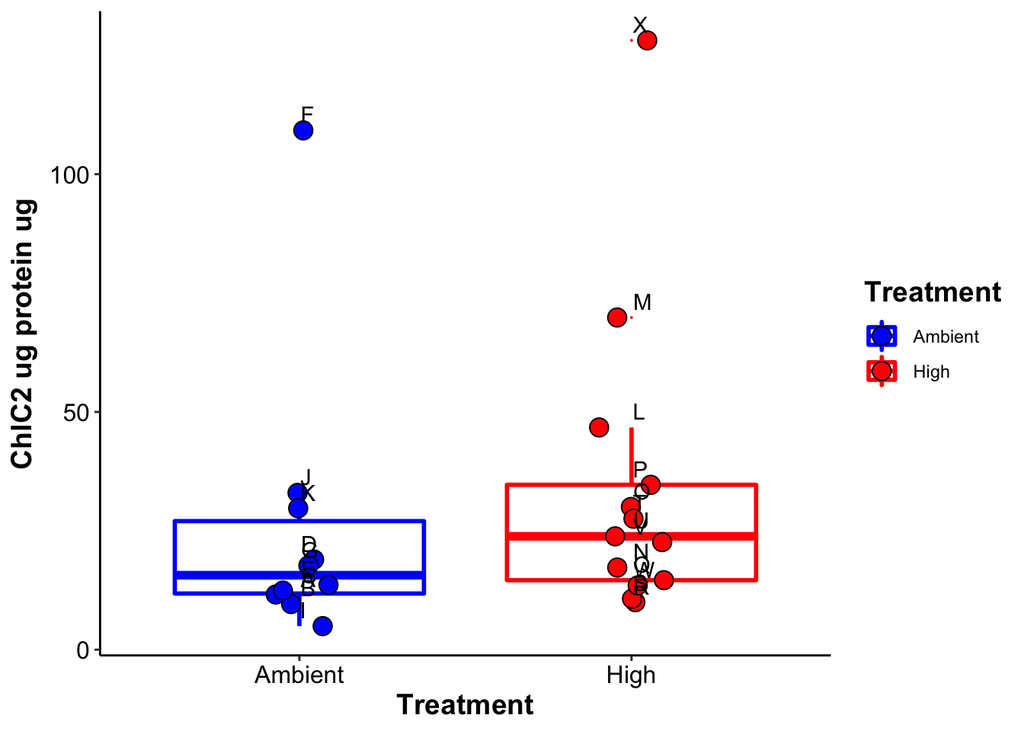

```r
chlC2_protein_plot<-df_mean %>%
    #filter(!Sample.ID=="H")%>%
    ggplot(., aes(x = as.factor(Treatment), y = chlC2.ug.protein.ug)) +
    geom_boxplot(aes(color=Treatment), outlier.size = 0, lwd=1) +
    geom_point(aes(fill=Treatment), pch = 21, size=4, position = position_jitterdodge(0.2)) +
    scale_fill_manual(values=c("blue", "red"))+
  scale_color_manual(values=c("blue", "red"))+
    geom_text(aes(label=Sample.ID), vjust = -0.5, hjust=-0.1)+
    xlab("Treatment") +
    ylab(expression(bold(paste("ChlC2 ug protein ug"))))+
    theme_classic() +
    theme(
      legend.position="right",
      axis.title=element_text(face="bold", size=14),
      axis.text=element_text(size=12, color="black"),
      legend.title=element_text(face="bold", size=14)
      ); chlC2_protein_plot
```

Run ANOVA.

```r
chlc2_prot_model<-aov(chlC2.ug.protein.ug~Treatment, data=df_mean)
summary(chlc2_prot_model)
```

```
##             Df Sum Sq Mean Sq F value Pr(>F)
## Treatment    1    408   408.3   0.405  0.531
## Residuals   21  21150  1007.2
```

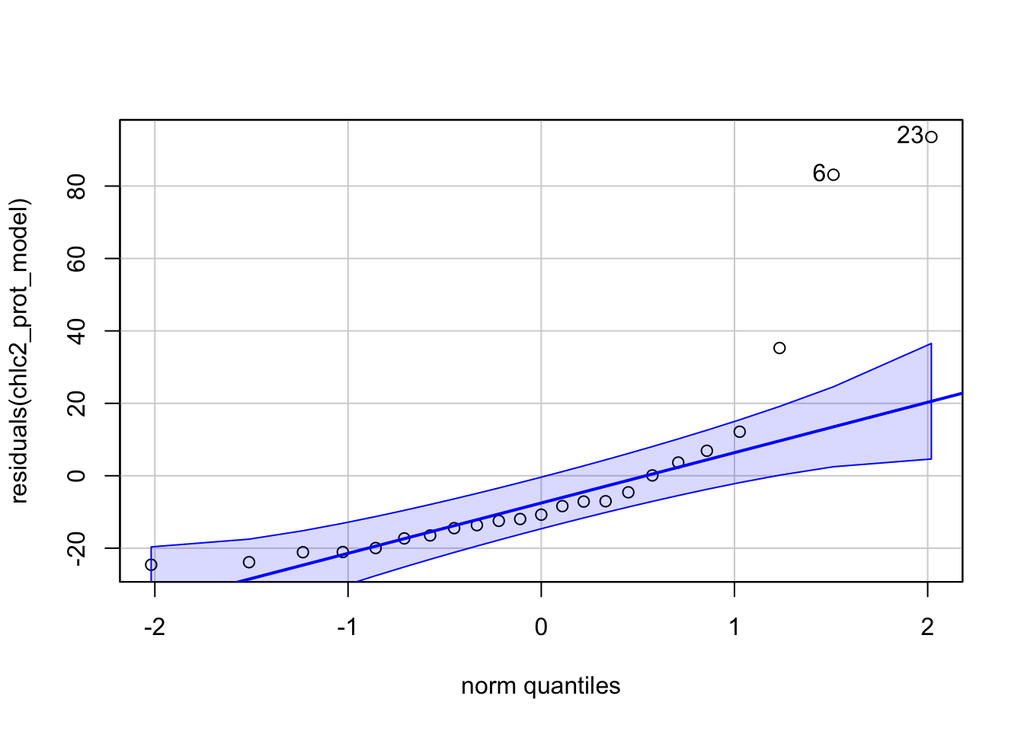

```
## [1] 23  6
```

```r
car::qqPlot(residuals(chlc2_prot_model))
```

```r
car::leveneTest(residuals(chlc2_prot_model)~Treatment, data=df_mean)
```

```
## Levene's Test for Homogeneity of Variance (center = median)
##       Df F value Pr(>F)
## group  1  0.0858 0.7724
##       21
```

No significant difference.

## Total chlorophyll

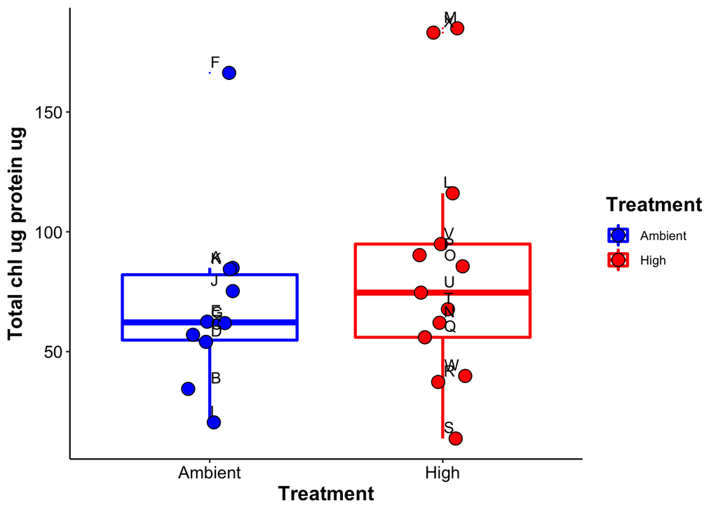

```r
chl.total_protein_plot<-df_mean %>%
    #filter(!Sample.ID=="H")%>%
    ggplot(., aes(x = as.factor(Treatment), y = total.chl.ug.protein.ug)) +
    geom_boxplot(aes(color=Treatment), outlier.size = 0, lwd=1) +
    geom_point(aes(fill=Treatment), pch = 21, size=4, position = position_jitterdodge(0.2)) +
    scale_fill_manual(values=c("blue", "red"))+
  scale_color_manual(values=c("blue", "red"))+
    geom_text(aes(label=Sample.ID), vjust = -0.5, hjust=-0.1)+
    xlab("Treatment") +
    ylab(expression(bold(paste("Total chl ug protein ug"))))+
    theme_classic() +
    theme(
      legend.position="right",
      axis.title=element_text(face="bold", size=14),
      axis.text=element_text(size=12, color="black"),
      legend.title=element_text(face="bold", size=14)
      ); chl.total_protein_plot
```

Plot total chl per protein with points and error bars.

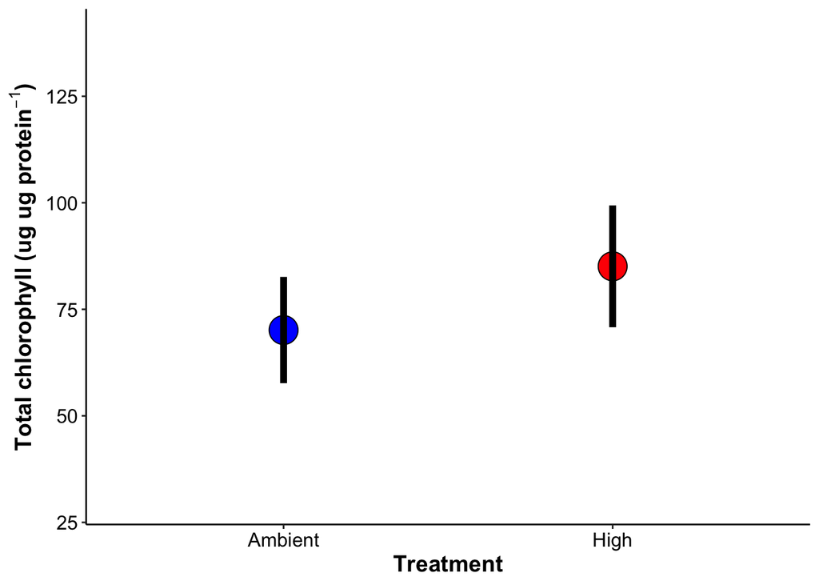

```r
chl.total_protein_plot_b<-df_mean %>%
    dplyr::group_by(Treatment)%>%
    dplyr::summarise(mean=mean(total.chl.ug.protein.ug), se=sd(total.chl.ug.protein.ug)/sqrt(length(total.chl.ug.protein.ug)))%>%


    ggplot(., aes(x = as.factor(Treatment), y = mean)) +
    geom_point(aes(fill=Treatment), pch = 21, size=8) +
    geom_errorbar(aes(ymin=mean-se, ymax=mean+se, group=Treatment), pch = 21, size=2, width=0) +
    scale_fill_manual(values=c("blue", "red"))+
    scale_color_manual(values=c("blue", "red"))+
    xlab("Treatment") +
    ylim(30, 140)+
    ylab(expression(bold(paste("Total chlorophyll (ug ug protein"^-1, ")"))))+
    theme_classic() +
    theme(
      legend.position="none",
      axis.title=element_text(face="bold", size=14),
      axis.text=element_text(size=12, color="black"),
      legend.title=element_text(face="bold", size=14)
      ); chl.total_protein_plot_b
```

```r
#Save plot
ggsave(chl.total_protein_plot_b, file="Mcap2021/Figures/chlorophyll_protein.png", w=4, h=4)
```

Run ANOVA.

```r
chl.total_prot_model<-aov(total.chl.ug.protein.ug~Treatment, data=df_mean)
summary(chl.total_prot_model)
```

```
##             Df Sum Sq Mean Sq F value Pr(>F)
## Treatment    1   1264    1264   0.579  0.455
## Residuals   21  45867    2184
```

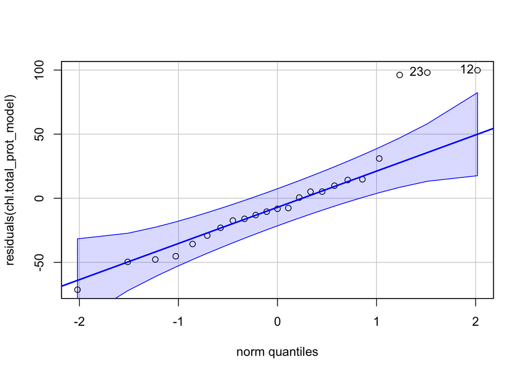

```
## [1] 12 23
```

```r
car::qqPlot(residuals(chl.total_prot_model))
```

```r
car::leveneTest(residuals(chl.total_prot_model)~Treatment, data=df_mean)
```

```
## Levene's Test for Homogeneity of Variance (center = median)
##       Df F value Pr(>F)
## group  1  0.7323 0.4018
##       21
```

No significant difference.

# **Normalize to cell density**

First, pull out cells per uL from the “Holo” tube for each sample, from which we took the symbiont sample.

```r
cells<-read.csv("Mcap2021/Output/Cells/cells_output.csv")

cells<-cells%>%
  dplyr::select(Sample.ID, Treatment, cells.uL)%>%
  dplyr::rename(Tube.ID=Sample.ID)
```

Next, divide chlA and chlC2 (ug.uL) by cells (uL) for each sample.

```r
df_mean$cells.uL<-cells$cells.uL[match(df_mean$Tube.ID, cells$Tube.ID)]
```

```r
df_mean$chlA.ug.cell<-df_mean$mean_chlA.ug.ul/df_mean$cells.uL
df_mean$chlC2.ug.cell<-df_mean$mean_chlC2.ug.ul/df_mean$cells.uL
df_mean$total.chl.ug.cell<-df_mean$total.chl.ug.uL/df_mean$cells.uL
```

Plot results.

## ChlA

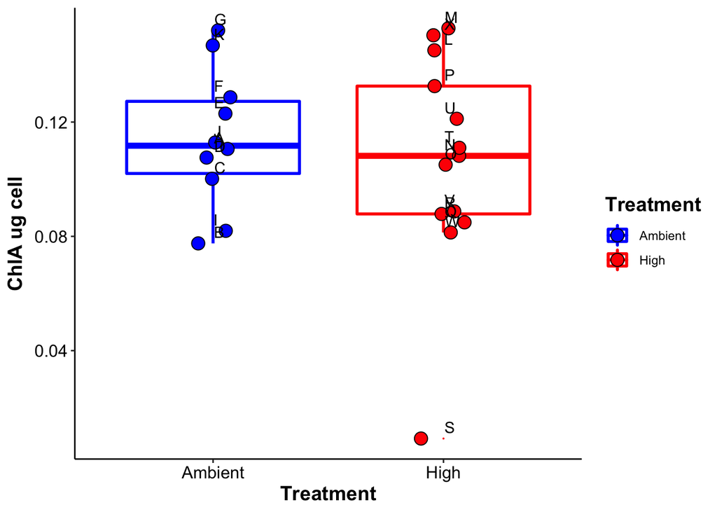

```r
chlA_cell_plot<-df_mean %>%
    #filter(!Sample.ID=="H")%>%
    ggplot(., aes(x = as.factor(Treatment), y = chlA.ug.cell)) +
    geom_boxplot(aes(color=Treatment), outlier.size = 0, lwd=1) +
    geom_point(aes(fill=Treatment), pch = 21, size=4, position = position_jitterdodge(0.2)) +
    scale_fill_manual(values=c("blue", "red"))+
  scale_color_manual(values=c("blue", "red"))+
    geom_text(aes(label=Sample.ID), vjust = -0.5, hjust=-0.1)+
    xlab("Treatment") +
    ylab(expression(bold(paste("ChlA ug cell"))))+
    theme_classic() +
    theme(
      legend.position="right",
      axis.title=element_text(face="bold", size=14),
      axis.text=element_text(size=12, color="black"),
      legend.title=element_text(face="bold", size=14)
      ); chlA_cell_plot
```

Run ANOVA.

```r
chla_cell_model<-aov(chlA.ug.cell~Treatment, data=df_mean)
summary(chla_cell_model)
```

```
##             Df  Sum Sq   Mean Sq F value Pr(>F)
## Treatment    1 0.00037 0.0003697   0.336  0.569
## Residuals   21 0.02313 0.0011013
```

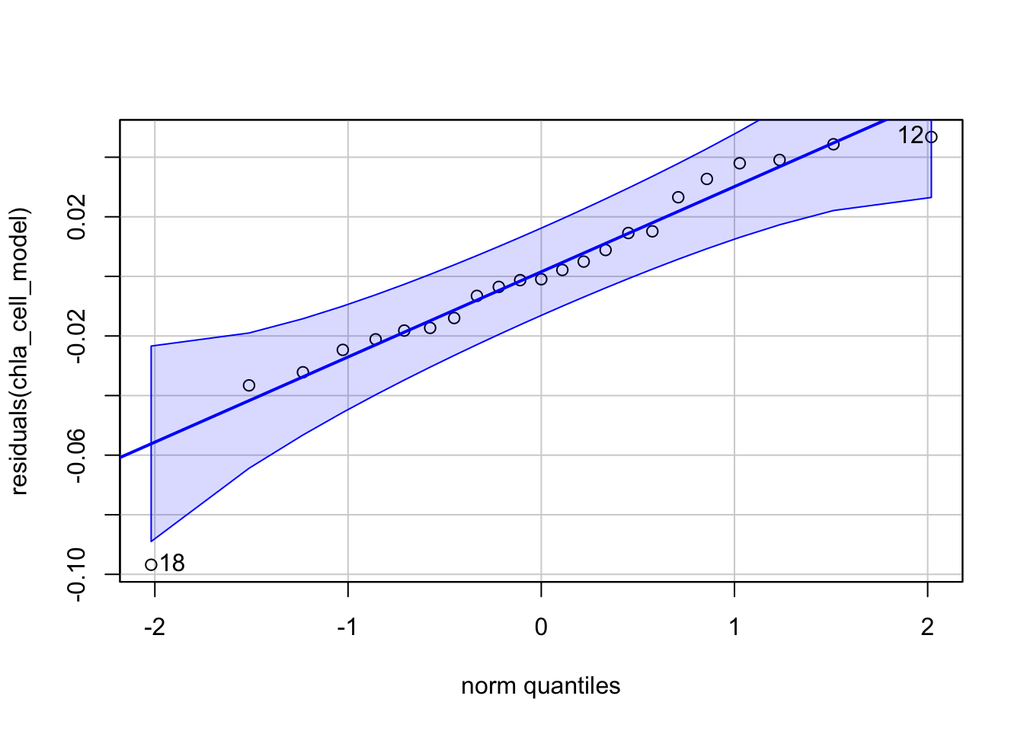

```
## [1] 18 12
```

```r
car::qqPlot(residuals(chla_cell_model))
```

```r
car::leveneTest(residuals(chla_cell_model)~Treatment, data=df_mean)
```

```
## Levene's Test for Homogeneity of Variance (center = median)
##       Df F value Pr(>F)
## group  1  0.9165 0.3493
##       21
```

Both normality and homogeneity of variance pass.

No significant difference.

## ChlC2

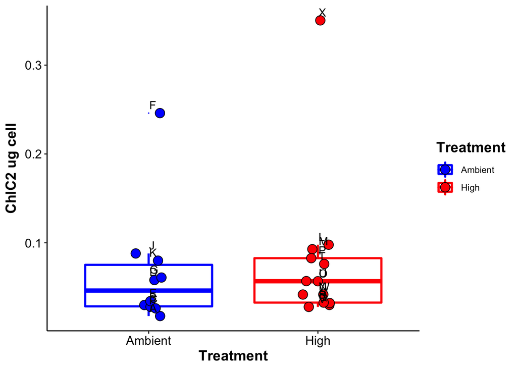

```r
chlC2_cell_plot<-df_mean %>%
    #filter(!Sample.ID=="H")%>%
    ggplot(., aes(x = as.factor(Treatment), y = chlC2.ug.cell)) +
    geom_boxplot(aes(color=Treatment), outlier.size = 0, lwd=1) +
    geom_point(aes(fill=Treatment), pch = 21, size=4, position = position_jitterdodge(0.2)) +
    scale_fill_manual(values=c("blue", "red"))+
  scale_color_manual(values=c("blue", "red"))+
    geom_text(aes(label=Sample.ID), vjust = -0.5, hjust=-0.1)+
    xlab("Treatment") +
    ylab(expression(bold(paste("ChlC2 ug cell"))))+
    theme_classic() +
    theme(
      legend.position="right",
      axis.title=element_text(face="bold", size=14),
      axis.text=element_text(size=12, color="black"),
      legend.title=element_text(face="bold", size=14)
      ); chlC2_cell_plot
```

Run ANOVA.

```r
chlc2_cell_model<-aov(chlC2.ug.cell~Treatment, data=df_mean)
summary(chlc2_cell_model)
```

```
##             Df  Sum Sq  Mean Sq F value Pr(>F)
## Treatment    1 0.00075 0.000754   0.124  0.729
## Residuals   21 0.12820 0.006105
```

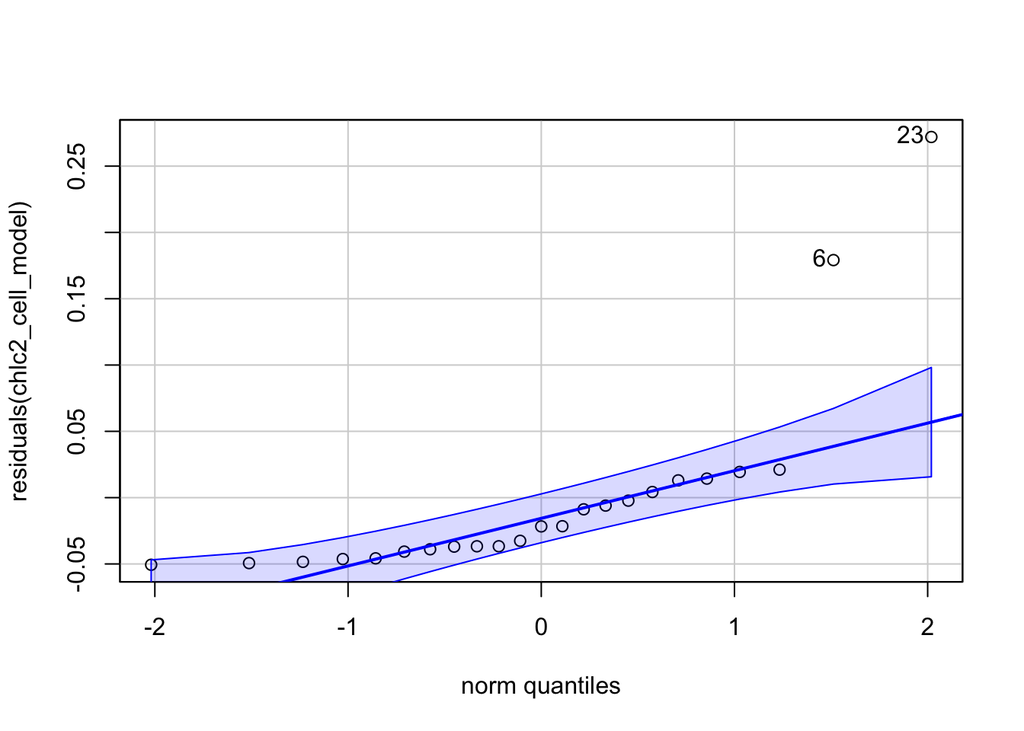

```
## [1] 23  6
```

```r
car::qqPlot(residuals(chlc2_cell_model))
```

```r
car::leveneTest(residuals(chlc2_cell_model)~Treatment, data=df_mean)
```

```
## Levene's Test for Homogeneity of Variance (center = median)
##       Df F value Pr(>F)
## group  1  0.0084 0.9278
##       21
```

No significant difference.

## Total chlorophyll

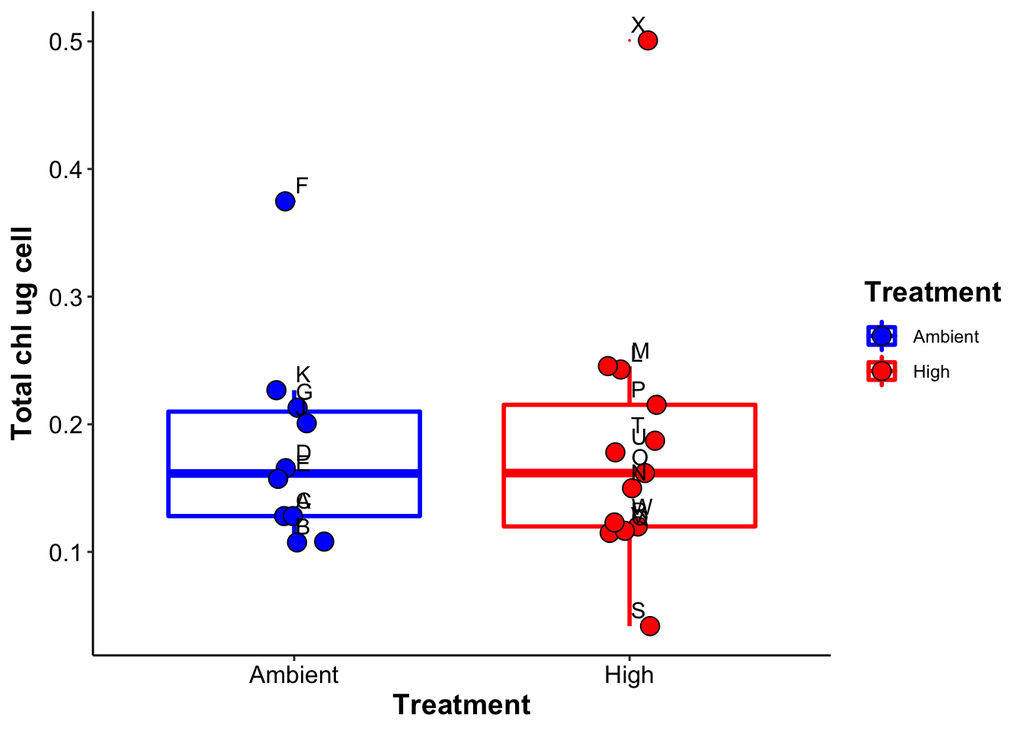

```r
chl.total_cell_plot<-df_mean %>%
    #filter(!Sample.ID=="H")%>%
    ggplot(., aes(x = as.factor(Treatment), y = total.chl.ug.cell)) +
    geom_boxplot(aes(color=Treatment), outlier.size = 0, lwd=1) +
    geom_point(aes(fill=Treatment), pch = 21, size=4, position = position_jitterdodge(0.2)) +
    scale_fill_manual(values=c("blue", "red"))+
  scale_color_manual(values=c("blue", "red"))+
    geom_text(aes(label=Sample.ID), vjust = -0.5, hjust=-0.1)+
    xlab("Treatment") +
    ylab(expression(bold(paste("Total chl ug cell"))))+
    theme_classic() +
    theme(
      legend.position="right",
      axis.title=element_text(face="bold", size=14),
      axis.text=element_text(size=12, color="black"),
      legend.title=element_text(face="bold", size=14)
      ); chl.total_cell_plot
```

Plot total chl per cell with points and error bars.

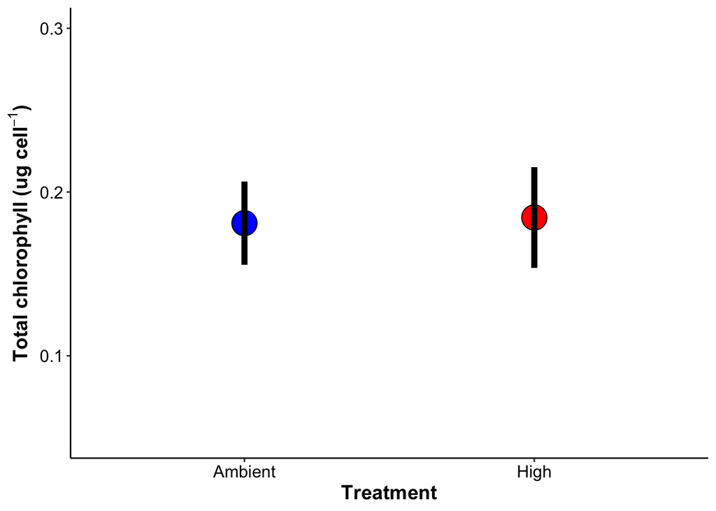

```r
chl.total_cell_plot_b<-df_mean %>%
    dplyr::group_by(Treatment)%>%
    dplyr::summarise(mean=mean(total.chl.ug.cell), se=sd(total.chl.ug.cell)/sqrt(length(total.chl.ug.cell)))%>%


    ggplot(., aes(x = as.factor(Treatment), y = mean)) +
    geom_point(aes(fill=Treatment), pch = 21, size=8) +
    geom_errorbar(aes(ymin=mean-se, ymax=mean+se, group=Treatment), pch = 21, size=2, width=0) +
    scale_fill_manual(values=c("blue", "red"))+
    scale_color_manual(values=c("blue", "red"))+
    xlab("Treatment") +
    ylim(0.05, 0.3)+
    ylab(expression(bold(paste("Total chlorophyll (ug cell"^-1, ")"))))+
    theme_classic() +
    theme(
      legend.position="none",
      axis.title=element_text(face="bold", size=14),
      axis.text=element_text(size=12, color="black"),
      legend.title=element_text(face="bold", size=14)
      ); chl.total_cell_plot_b
```

```r
#Save plot
ggsave(chl.total_cell_plot_b, file="Mcap2021/Figures/chlorophyll_cell.png", w=4, h=4)
```

Run ANOVA.

```r
chl.total_cell_model<-aov(total.chl.ug.cell~Treatment, data=df_mean)
summary(chl.total_cell_model)
```

```
##             Df  Sum Sq  Mean Sq F value Pr(>F)
## Treatment    1 0.00007 0.000068   0.007  0.935
## Residuals   21 0.20575 0.009798
```

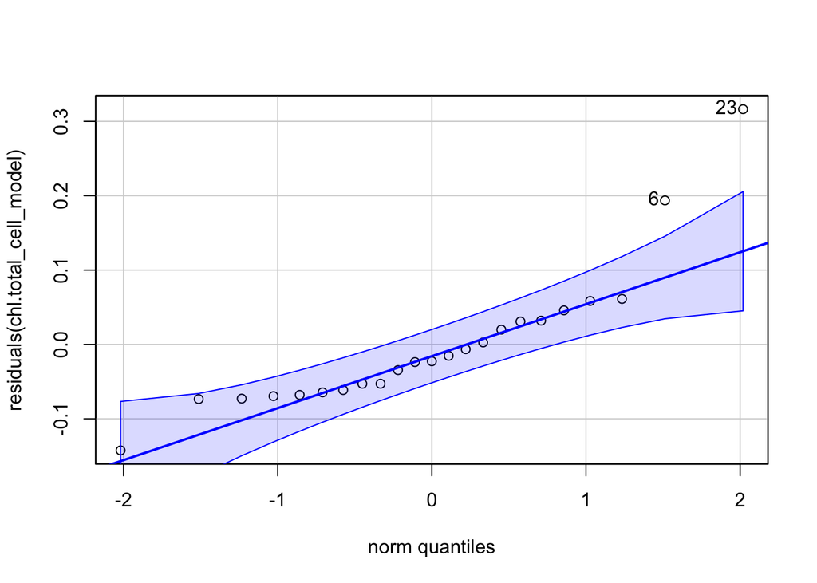

```
## [1] 23  6
```

```r
car::qqPlot(residuals(chl.total_cell_model))
```

```r
car::leveneTest(residuals(chl.total_cell_model)~Treatment, data=df_mean)
```

```
## Levene's Test for Homogeneity of Variance (center = median)
##       Df F value Pr(>F)
## group  1  0.1975 0.6613
##       21
```

No significant difference.